# APCalign

## Align and update plant taxon names

Now we can query our taxonomic names against the taxonomic resources we just retrieved using `create_taxonomic_update_lookup()`. This all-in-one function will:

- Align your taxonomic names to APC and APNI using our [matching algorithms](https://traitecoevo.github.io/APCalign/articles/updating-taxon-names.html)
- Update names to an APC-accepted species or infraspecific name whenever possible.
- Return a suggested name for all names, defaulting to an `accepted_name` when available, and otherwise providing an APNI name or a name where only a genus-level alignment is possible.

If you would like to learn more about each of these step, take a look at the section Closer look at name alignment and updating with ‘APCalign’

```r
library(dplyr)
updated_gbif_names <- gbif_lite |>
  pull(species) |>
  create_taxonomic_update_lookup(resources = resources)
```

```
#> Checking alignments of 121 taxa
#>   -> of these 112 names have a perfect match to a scientific name in the APC.
#>       Alignments being sought for remaining names.
```

```r
updated_gbif_names |>
  print(n = 6)
```

```
#> # A tibble: 129 × 12
#>   original_name           aligned_name      accepted_name suggested_name genus taxon_rank taxonomic_dataset taxonomic_status
#>   <chr>                   <chr>             <chr>         <chr>          <chr> <chr>      <chr>             <chr>
#> 1 Tetratheca ciliata      Tetratheca cilia… Tetratheca c… Tetratheca ci… Tetr… species    APC               accepted
#> 2 Peganum harmala         Peganum harmala   Peganum harm… Peganum harma… Pega… species    APC               accepted
#> 3 Calotis multicaulis     Calotis multicau… Calotis mult… Calotis multi… Calo… species    APC               accepted
#> 4 Leptospermum trinervium Leptospermum tri… Leptospermum… Leptospermum … Lept… species    APC               accepted
#> 5 Lepidosperma laterale   Lepidosperma lat… Lepidosperma… Lepidosperma … Lepi… species    APC               accepted
#> 6 Enneapogon polyphyllus  Enneapogon polyp… Enneapogon p… Enneapogon po… Enne… species    APC               accepted
#> # ℹ 123 more rows
#> # ℹ 4 more variables: scientific_name <chr>, aligned_reason <chr>, update_reason <chr>, number_of_collapsed_taxa <dbl>
```

The `original_name` is the taxon name used in your original data. The `aligned_name` is the taxon name we used to link with the APC to identify any synonyms. The `accepted_name` is the currently, accepted taxon name used by the Australian Plant Census. The `suggested_name` is the best possible name option for the `original_name`.

## Plant established status across states/territories

‘APCalign’ can also provide the state/territory distribution for established status (native/introduced) from the APC.

We can access the established status data by state/territory using `create_species_state_origin_matrix()`

You can specify to include infrataxa (subspecies, varieties and forms) using `include_infrataxa = TRUE`, or generate statistics just for species using `include_infrataxa = FALSE`.

```r
# Retrieve status data by state/territory
status_matrix <- create_species_state_origin_matrix(resources = resources, include_infrataxa = TRUE)
```

Here is a breakdown of all possible values for `origin`

```r
library(purrr)
library(janitor)
# Obtain unique values for establishment status
status_matrix |>
  tidyr::pivot_longer(4:21) |>
  filter(value != "not present") |>
  distinct(value)

# value
# <chr>
#   1 native
# 2 naturalised
# 3 doubtfully naturalised
# 4 native and naturalised
# 5 formerly naturalised
# 6 presumed extinct
# 7 uncertain origin
# 8 native and uncertain origin
# 9 native and doubtfully naturalised
```

```r
status_matrix |> select(family, species, ACT:WA) |> print(n=20)
```

You can also obtain the breakdown of species by established status for a particular state/territory using `state_diversity_counts()`

```r
state_diversity_counts("NSW", resources = resources)
```

```
#> # A tibble: 7 × 3
#>   origin                            state num_species
#>   <chr>                             <chr> <table[1d]>
#> 1 doubtfully naturalised            NSW     93
#> 2 formerly naturalised              NSW      8
#> 3 native                            NSW   5968
#> 4 native and doubtfully naturalised NSW      2
#> 5 native and naturalised            NSW     34
#> 6 naturalised                       NSW   1580
#> 7 presumed extinct                  NSW      8
```

Using the established status data and state/territory information, we can check if a plant taxa is a native using `native_anywhere_in_australia()`

```r
library(dplyr)

updated_gbif_names |>
  sample_n(1) |>  # Choosing a random species
  pull(suggested_name) |> # Extracting this APC accepted name
  native_anywhere_in_australia(resources = resources)
```

```
#> # A tibble: 1 × 2
#>   species             native_anywhere_in_aus
#>   <chr>               <chr>
#> 1 Lomandra longifolia native
```

## Closer look at name standardisation with ‘APCalign’

`create_taxonomic_update_lookup` is a simple, wrapper, function for novice users that want to quickly check and standardise taxon names. For more experienced users, you can take a look at the sub functions `match_taxa()`, `align_taxa()` and `update_taxonomy()` to see how taxon names are processed, aligned and updated.

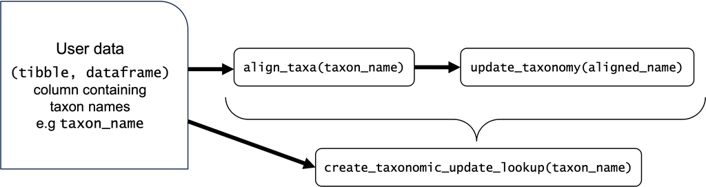

### Aligning names to APC and APNI

The function `align_taxa` will:

1. Clean up your taxonomic names
   - The functions `standardise_names`, `strip_names` and `strip_names_extra` standardise infraspecific taxon designations and clean up punctuation and whitespaces
2. Find best alignment with APC or APNI to your taxonomic name using our the function [match_taxa](https://traitecoevo.github.io/APCalign/articles/updating-taxon-names.html)
   - A taxonomic name flows through a progression of [50 match algorithms](https://traitecoevo.github.io/APCalign/articles/updating-taxon-names.html) until it is able to be aligned to a name on either the APC or APNI list.
   - These include exact and fuzzy matches. Fuzzy matches are designed to capture small spelling mistakes and syntax errors in phrase names.
   - These include matches to the entire name string and matches on just select words in the sequence.
   - The sequence of matches has been carefully curated to align names with the fewest mistakes.
3. Determine the `taxon_rank` to which the name can be resolved, based on its syntax.
   - For names that can only be resolved to genus, reformats the name to offer a standardised `genus sp.` name, with additional information/notes provided as part of the original name in square brackets, as in `Acacia sp. [skinny leaves]` or `Acacia sp. [Broken Hill]`
4. Determine the `taxonomic_reference` (APC or APNI) of each name-alignment.

**Note** that `align_taxa` **does not** seek to update outdated taxonomy. That process occurs during update_taxonomy process. `align_taxa` instead aligns each name input to the closest match amongst names documented by the APC and APNI.

```r
library(dplyr)

aligned_gbif_taxa <- gbif_lite |>
  pull(species) |>
  align_taxa(resources = resources)
```

```
#> Checking alignments of 121 taxa
#>   -> of these 112 names have a perfect match to a scientific name in the APC.
#>       Alignments being sought for remaining names.
```

```r
aligned_gbif_taxa |>
  print(n = 6)
```

```
#> # A tibble: 129 × 7
#>   original_name           cleaned_name            aligned_name    taxonomic_dataset taxon_rank aligned_reason alignment_code
#>   <chr>                   <chr>                   <chr>           <chr>             <chr>      <chr>          <chr>
#> 1 Tetratheca ciliata      Tetratheca ciliata      Tetratheca cil… APC               species    Exact match o… match_01c_acc…
#> 2 Peganum harmala         Peganum harmala         Peganum harmala APC               species    Exact match o… match_01c_acc…
#> 3 Calotis multicaulis     Calotis multicaulis     Calotis multic… APC               species    Exact match o… match_01c_acc…
#> 4 Leptospermum trinervium Leptospermum trinervium Leptospermum t… APC               species    Exact match o… match_01c_acc…
#> 5 Lepidosperma laterale   Lepidosperma laterale   Lepidosperma l… APC               species    Exact match o… match_01c_acc…
#> 6 Enneapogon polyphyllus  Enneapogon polyphyllus  Enneapogon pol… APC               species    Exact match o… match_01c_acc…
#> # ℹ 123 more rows
```

For every `aligned_name`, `align_taxa()` will provide a `aligned_reason` which you can review as a table of counts:

```r
library(janitor)

aligned_gbif_taxa |>
  pull(aligned_reason) |>
  tabyl() |>
  tibble()
```

```
#> # A tibble: 6 × 4
#>   `pull(aligned_gbif_taxa, aligned_reason)`                                                          n percent valid_percent
#>   <chr>                                                                                          <int>   <dbl>         <dbl>
#> 1 Exact match of taxon name to an APC-accepted canonical name once punctuation and filler words…   118 0.915         0.929
#> 2 Exact match of taxon name to an APC-known canonical name once punctuation and filler words ar…     6 0.0465        0.0472
#> 3 Exact match of taxon name to an APNI-listed canonical name once punctuation and filler words …     1 0.00775       0.00787
#> 4 Exact match of the first two words of the taxon name to an APC-accepted canonical name (2024-…     1 0.00775       0.00787
#> 5 Exact match of the first word of the taxon name to an APC-accepted genus (2024-11-14)              1 0.00775       0.00787
#> 6 <NA>                                                                                               2 0.0155       NA
```

#### Configuring matching precision and aligned output

There are arguments in `align_taxa` that allows you to select which of the 50 matching algorithms are activated/deactivated and the degree of fuzziness of the fuzzy matching function

- `fuzzy_matches` turns fuzzy matching on / off (it defaults to `TRUE`).
- `fuzzy_abs_dist` and `fuzzy_rel_dist` control the degree of fuzzy matching (they default to `fuzzy_abs_dist = 3` & `fuzzy_rel_dist = 0.2`).
- `imprecise_fuzzy_matches` turns imprecise fuzzy matching on / off (it defaults to `FALSE`; for true it is set to `fuzzy_abs_dist = 5` & `fuzzy_rel_dist = 0.25`).
- `APNI_matches` turns matches to the APNI list on/off (it defaults to `TRUE`).
- `identifier` allows you to specify a text string that is added to genus-level matches, indicating the site, study, etc e.g. `Acacia sp. [Blue Mountains]`

### Updating to APC-accepted names

`update_taxonomy()` uses the information generated by `align_taxa()` to, whenever possible, update names to APC-accepted names.

```r
updated_gbif_taxa <- aligned_gbif_taxa |>
  update_taxonomy(resources = resources)

updated_gbif_taxa |>
  print(n = 6)
```

```
#> # A tibble: 129 × 21
#>   original_name         aligned_name accepted_name suggested_name genus family taxon_rank taxonomic_dataset taxonomic_status
#>   <chr>                 <chr>        <chr>         <chr>          <chr> <chr>  <chr>      <chr>             <chr>
#> 1 Tetratheca ciliata    Tetratheca … Tetratheca c… Tetratheca ci… Tetr… Elaeo… species    APC               accepted
#> 2 Peganum harmala       Peganum har… Peganum harm… Peganum harma… Pega… Nitra… species    APC               accepted
#> 3 Calotis multicaulis   Calotis mul… Calotis mult… Calotis multi… Calo… Aster… species    APC               accepted
#> 4 Leptospermum trinerv… Leptospermu… Leptospermum… Leptospermum … Lept… Myrta… species    APC               accepted
#> 5 Lepidosperma laterale Lepidosperm… Lepidosperma… Lepidosperma … Lepi… Cyper… species    APC               accepted
#> 6 Enneapogon polyphyll… Enneapogon … Enneapogon p… Enneapogon po… Enne… Poace… species    APC               accepted
#> # ℹ 123 more rows
#> # ℹ 12 more variables: taxonomic_status_aligned <chr>, aligned_reason <chr>, update_reason <chr>, subclass <chr>,
#> #   taxon_distribution <chr>, scientific_name <chr>, taxon_ID <chr>, taxon_ID_genus <chr>, scientific_name_ID <chr>,
#> #   canonical_name <chr>, row_number <dbl>, number_of_collapsed_taxa <dbl>
```

#### Taxonomic resources used for updating names

- The APC includes all previously recorded taxonomic names for a current taxon concept, designating the currently-accepted name as `taxonomic_status: accepted`, while previously used or inappropriately used names for the taxon concept have alternative taxonomic statuses documented (e.g. taxonomic synonym, orthographic variant, misapplied).
- The APC includes a column `acceptedNameUsageID` that links a taxon name with an alternative taxonomic status to the current taxon name, allowing outdated/inappropriately used names to be synced to their current name.

*Note*: Names listed on the APNI but absent from the APC are those that are designated as `taxonomic_dataset: APNI` by `APCalign`. These are names that are currently `unknown` by the APC. Over time, this list shrinks, as taxonomists link ever more occasionally used name variants to an APC-accepted taxon. However, for now, *names listed only on the APNI cannot be updated*

#### Name updates at different taxonomic levels

- `update_taxonomy()` divides names into lists based on the `taxon_rank` and `taxonomic_dataset` assigned by `align_taxa`, as each list requires different updating algorithms.
- Only taxonomic names that are designated as `taxon_rank = species/infraspecific` and `taxonomic_dataset = APC` can be updated to an APC-accepted name.
- For all other taxa, it may be possible to align the genus-name to an APC-accepted genus.
- For all taxa, a `suggested_name` is provided, selecting the `accepted_name` when available, and otherwise the `aligned_name`, but with, if possible, an updated, APC-accepted genus name.

#### Taxonomic splits

```r
library(dplyr)

aligned_gbif_taxa |>
  update_taxonomy(taxonomic_splits = "most_likely_species",
                  resources = resources)  |>
  filter(original_name == "Acacia aneura")  # Subsetting Acacia aneura as an example
```

```
#> # A tibble: 1 × 21
#>   original_name aligned_name  accepted_name suggested_name        genus family taxon_rank taxonomic_dataset taxonomic_status
#>   <chr>         <chr>         <chr>         <chr>                 <chr> <chr>  <chr>      <chr>             <chr>
#> 1 Acacia aneura Acacia aneura Acacia aneura Acacia aneura [alter… Acac… Fabac… species    APC               accepted
#> # ℹ 12 more variables: taxonomic_status_aligned <chr>, aligned_reason <chr>, update_reason <chr>, subclass <chr>,
#> #   taxon_distribution <chr>, scientific_name <chr>, taxon_ID <chr>, taxon_ID_genus <chr>, scientific_name_ID <chr>,
#> #   canonical_name <chr>, row_number <dbl>, number_of_collapsed_taxa <dbl>
```

```r
aligned_gbif_taxa |>
  update_taxonomy(taxonomic_splits = "return_all",
                  resources = resources)  |>
  filter(original_name == "Acacia aneura") # Subsetting Acacia aneura as an example
```

```
#> # A tibble: 3 × 21
#>   original_name aligned_name  accepted_name    suggested_name   genus  family  taxon_rank taxonomic_dataset taxonomic_status
#>   <chr>         <chr>         <chr>            <chr>            <chr>  <chr>   <chr>      <chr>             <chr>
#> 1 Acacia aneura Acacia aneura Acacia aneura    Acacia aneura    Acacia Fabace… species    APC               accepted
#> 2 Acacia aneura Acacia aneura Acacia minyura   Acacia minyura   Acacia Fabace… species    APC               accepted
#> 3 Acacia aneura Acacia aneura Acacia paraneura Acacia paraneura Acacia Fabace… species    APC               accepted
#> # ℹ 12 more variables: taxonomic_status_aligned <chr>, aligned_reason <chr>, update_reason <chr>, subclass <chr>,
#> #   taxon_distribution <chr>, scientific_name <chr>, taxon_ID <chr>, taxon_ID_genus <chr>, scientific_name_ID <chr>,
#> #   canonical_name <chr>, row_number <dbl>, number_of_collapsed_taxa <dbl>
```

```r
aligned_gbif_taxa |>
  update_taxonomy(taxonomic_splits = "collapse_to_higher_taxon",
                  resources = resources)  |>
  filter(original_name == "Acacia aneura") # Subsetting Acacia aneura as an example
```

```
#> # A tibble: 1 × 21
#>   original_name aligned_name  accepted_name suggested_name        genus family taxon_rank taxonomic_dataset taxonomic_status
#>   <chr>         <chr>         <chr>         <chr>                 <chr> <chr>  <chr>      <chr>             <chr>
#> 1 Acacia aneura Acacia aneura Acacia sp.    Acacia sp. [collapse… Acac… Fabac… species    APC               accepted
#> # ℹ 12 more variables: taxonomic_status_aligned <chr>, aligned_reason <chr>, update_reason <chr>, subclass <chr>,
#> #   taxon_distribution <chr>, scientific_name <chr>, taxon_ID <chr>, taxon_ID_genus <chr>, scientific_name_ID <chr>,
#> #   canonical_name <chr>, row_number <dbl>, number_of_collapsed_taxa <dbl>
```

### Generating lists of synonyms

`synonyms_for_accepted_names()` compiles a table of all outdated and misapplied names which once applied to an accepted taxon name. The output can be in a condensed format, with the synonyms for an accepted name appearing in a single cell, or in a long format, with a separate row for each synonym. Both formats indicate each synonyms “type” - `nomenclatural_synonym`, `taxonomic_synonym`, `orthographic_variant`, `misapplied`, etc. This function is particularly useful for research applications where you know a currently accepted taxon name and want to indicate part names that apply, to document the links or to efficiently search the literature.

```r
> names_to_check <- c("Acacia aneura", "Banksia nivea", "Cardamine gunnii", "Stenocarpus sinuatus")
> synonyms_for_accepted_names(resources = resources, accepted_names = names_to_check, collapse = TRUE)

# A tibble: 4 × 8
#  family       accepted_name        synonyms                                                                                                                           taxon_rank name_type scientific_name accepted_name_usage_ID genus
#  <chr>        <chr>                <chr>                                                                                                                              <chr>      <chr>     <chr>           <chr>                  <chr>
#1 Brassicaceae Cardamine gunnii     Cardamine hirsuta var. heterophylla (taxonomic synonym); Cardamine hirsuta var. debilis (taxonomic synonym); Cardamine gunnii, ty… species    scientif… Cardamine gunn… https://id.biodiversi… Card…
#2 Fabaceae     Acacia aneura        Acacia aneura var. intermedia (taxonomic synonym); Racosperma aneurum var. intermedium (taxonomic synonym); Acacia aneura var. (N… species    scientif… Acacia aneura … https://id.biodiversi… Acac…
#3 Proteaceae   Banksia nivea        Dryandra nivea var. venosa (taxonomic synonym); Josephia rachidifolia (taxonomic synonym); Dryandra nivea var. adscendens (taxono… species    scientif… Banksia nivea … https://id.biodiversi… Bank…
#4 Proteaceae   Stenocarpus sinuatus Agnostus sinuatus (taxonomic synonym); Agnostus sinuata (taxonomic synonym); Stenocarpus sinuosus var. intergrifolius (taxonomic … species    scientif… Stenocarpus si… https://id.biodiversi… Sten…
```

```r
names_to_check <- c("Acacia aneura", "Banksia nivea", "Cardamine gunnii", "Stenocarpus sinuatus")
> synonyms_for_accepted_names(resources = resources, accepted_names = names_to_check, collapse = FALSE)
# A tibble: 25 × 9
#    family       accepted_name    synonym                                            taxonomic_status      taxon_rank name_type  scientific_name                  accepted_name_usage_ID                           genus
#    <chr>        <chr>            <chr>                                              <fct>                 <chr>      <chr>      <chr>                            <chr>                                            <chr>
#  1 Brassicaceae Cardamine gunnii Cardamine hirsuta var. heterophylla                taxonomic synonym     species    scientific Cardamine gunnii Hewson          https://id.biodiversity.org.au/node/apni/2886061 Cardamine
#  2 Brassicaceae Cardamine gunnii Cardamine hirsuta var. debilis                     taxonomic synonym     species    scientific Cardamine gunnii Hewson          https://id.biodiversity.org.au/node/apni/2886061 Cardamine
#  3 Brassicaceae Cardamine gunnii Cardamine gunnii, type variant                     nomenclatural synonym species    scientific Cardamine gunnii Hewson          https://id.biodiversity.org.au/node/apni/2886061 Cardamine
#  4 Brassicaceae Cardamine gunnii Cardamine heterophylla var. heterophylla           nomenclatural synonym species    scientific Cardamine gunnii Hewson          https://id.biodiversity.org.au/node/apni/2886061 Cardamine
#  5 Brassicaceae Cardamine gunnii Cardamine heterophylla                             nomenclatural synonym species    scientific Cardamine gunnii Hewson          https://id.biodiversity.org.au/node/apni/2886061 Cardamine
#  6 Brassicaceae Cardamine gunnii Cardamine debilis                                  misapplied            species    scientific Cardamine gunnii Hewson          https://id.biodiversity.org.au/node/apni/2886061 Cardamine
#  7 Fabaceae     Acacia aneura    Acacia aneura var. intermedia                      taxonomic synonym     species    scientific Acacia aneura F.Muell. ex Benth. https://id.biodiversity.org.au/node/apni/6707550 Acacia
#  8 Fabaceae     Acacia aneura    Racosperma aneurum var. intermedium                taxonomic synonym     species    scientific Acacia aneura F.Muell. ex Benth. https://id.biodiversity.org.au/node/apni/6707550 Acacia
#  9 Fabaceae     Acacia aneura    Acacia aneura var. (Napperby S.L.Everist 4226)     taxonomic synonym     species    scientific Acacia aneura F.Muell. ex Benth. https://id.biodiversity.org.au/node/apni/6707550 Acacia
# 10 Fabaceae     Acacia aneura    Acacia aneura var. (Thargomindah D.E.Boyland 8099) taxonomic synonym     species    scientific Acacia aneura F.Muell. ex Benth. https://id.biodiversity.org.au/node/apni/6707550 Acacia
# ℹ 15 more rows
# ℹ Use `print(n = ...)` to see more rows
```